# Домашняя работа №1

Екатерина Химич

#### **Задание 1.** Загрузите датасет insurance_cost.csv

```r
library(readr)
read_csv("C:/R/insurance_cost.csv")
```

```
## # A tibble: 1,338 × 7
##      age sex      bmi children smoker region    charges
##    <dbl> <chr>  <dbl>    <dbl> <chr>  <chr>       <dbl>
##  1    19 female  27.9        0 yes    southwest  16885.
##  2    18 male    33.8        1 no     southeast   1726.
##  3    28 male    33          3 no     southeast   4449.
##  4    33 male    22.7        0 no     northwest  21984.
##  5    32 male    28.9        0 no     northwest   3867.
##  6    31 female  25.7        0 no     southeast   3757.
##  7    46 female  33.4        1 no     southeast   8241.
##  8    37 female  27.7        3 no     northwest   7282.
##  9    37 male    29.8        2 no     northeast   6406.
## 10    60 female  25.8        0 no     northwest  28923.
## # … with 1,328 more rows
```

```r
inc <- read_csv("C:/R/insurance_cost.csv")
#summary(inc)
#skim(inc)
```

#### **Задание 2.** Выведите гистограммы всех нумерических переменных

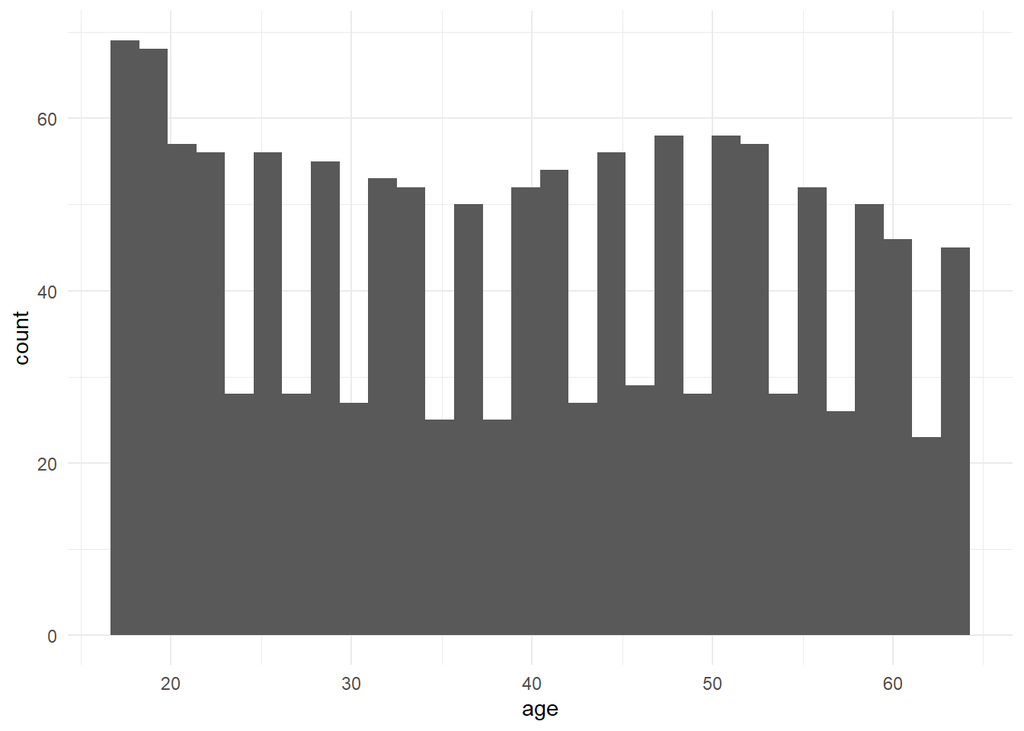

```r
library(ggplot2)

ggplot() +
  geom_histogram(data = inc,
                 aes(x = age),
                 bins = 30) +
  theme_minimal()
```

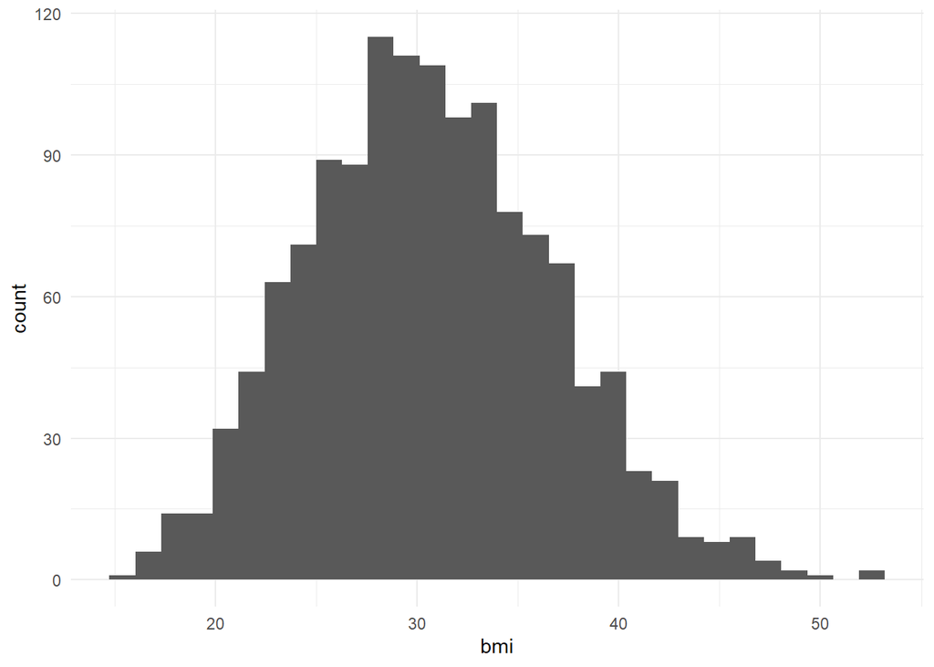

```r
ggplot() +
  geom_histogram(data = inc,
                 aes(x = bmi),
                 bins = 30) +
  theme_minimal()
```

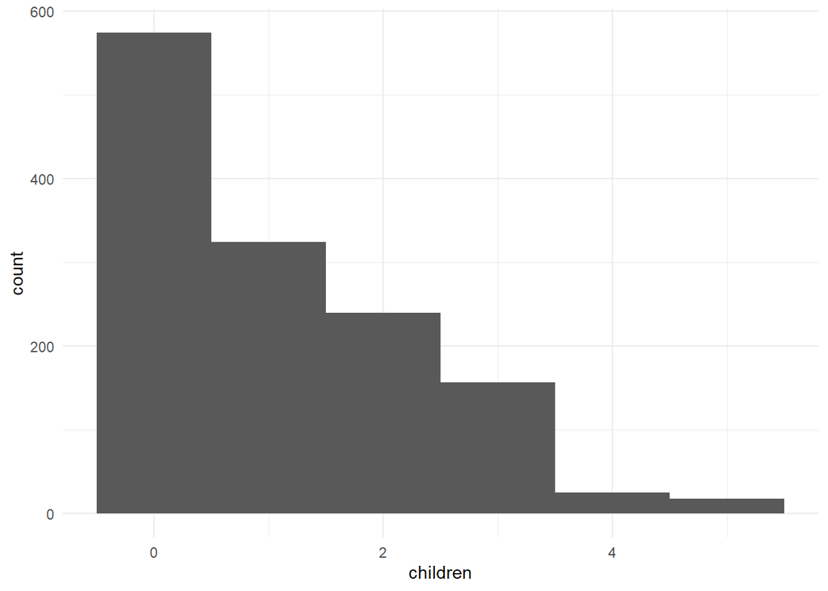

```r
ggplot() +
  geom_histogram(data = inc,
                 aes(x = children),
                 bins = 6) +
  theme_minimal()
```

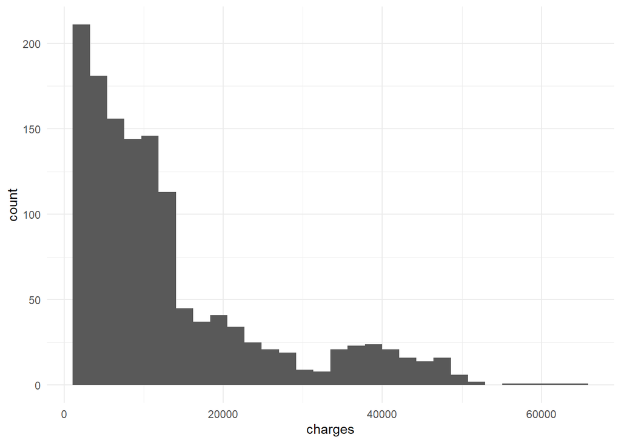

```r
ggplot() +
  geom_histogram(data = inc,
                 aes(x = charges),
                 bins = 30) +
  theme_minimal()
```

#### **Задание 3.** Нарисуйте график плотности по колонке charges. Отметьте вертикальные линии средней и медианы на графике. Раскрасьте текст и линии средней и медианы разными цветами. Добавьте текстовые пояснения значения средней и медианы. Подберите тему для графика. Назовите оси.

[figure not shown]

```r
#Среднее значение
charges_mean <- round(mean(inc$charges),1)

#Медиана
charges_med <- round(median(inc$charges),1)

#Построение графика
ggplot(data = inc) +
      geom_density(aes(x = charges)) +
      geom_vline(aes(xintercept = charges_mean), color = "violet") +
          annotate("text",
                   x= charges_mean + 7000,
                   y= 0.00005,
                   label = paste0 ("mean = ",charges_mean), color = "violet") +
        geom_vline(aes(xintercept = charges_med), color = "pink") +
          annotate("text",
                   x= charges_med - 5000,
                   y= 0.000063,
                   label = paste0 ("mean = ",charges_med), color = "pink") +
      theme_bw() +
  labs (y = 'Плотность', x = 'Выплаты')
```

#### **Задание 4.** Сделайте три box_plot по отношению переменных charges и (1) sex (2) smoker (3) region. Подберите тему для графика. Назовите оси

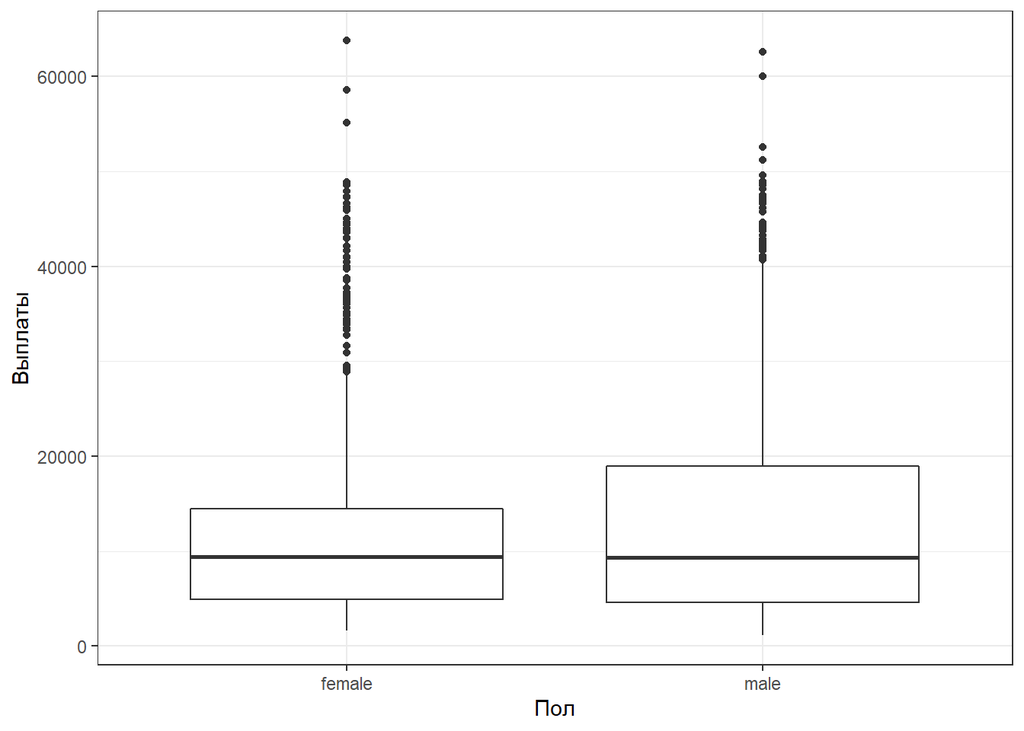

```r
ggplot(data = inc) +
      geom_boxplot(aes(x = charges, y = sex)) +
      theme_bw() +
  labs (x = 'Выплаты', y = 'Пол') +
  coord_flip()
```

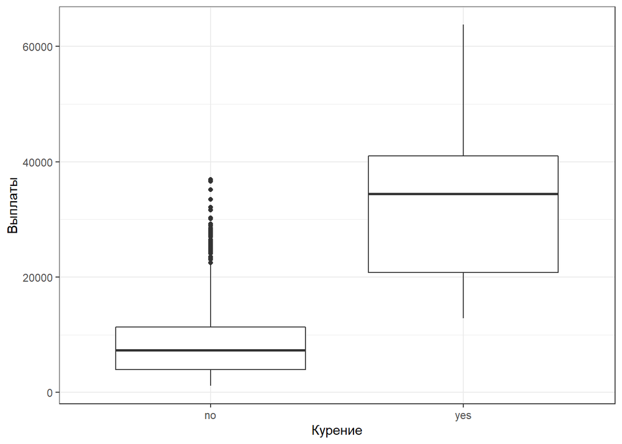

```r
ggplot(data = inc) +
      geom_boxplot(aes(x = charges, y = smoker)) +
      theme_bw() +
  labs (x = 'Выплаты', y = 'Курение') +
  coord_flip()
```

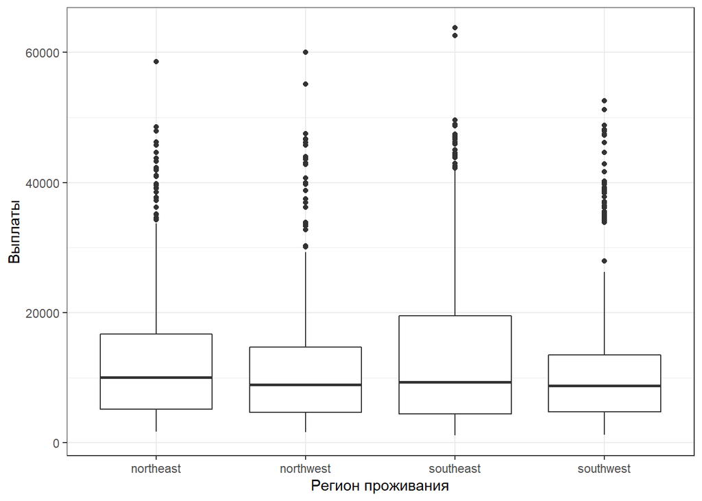

```r
ggplot(data = inc) +
      geom_boxplot(aes(x = charges, y = region)) +
      theme_bw() +
  labs (x = 'Выплаты', y = 'Регион проживания') +
  coord_flip()
```

#### **Задание 5.** Объедините графики из заданий 3 и 4 в один так, чтобы сверху шёл один график из задания 3, а под ним 3 графика из задания 4. Сделайте общее название для графика.

[figure not shown]

```r
library(ggpubr)

#Присваивание переменных для упрощения работы
a <- ggplot(data = inc) +
      geom_density(aes(x = charges)) +
      geom_vline(aes(xintercept = charges_mean), color = "violet") +
          annotate("text",
                   x= charges_mean + 7000,
                   y= 0.00005,
                   label = paste0 ("mean = ",charges_mean), color = "violet") +
        geom_vline(aes(xintercept = charges_med), color = "pink") +
          annotate("text",
                   x= charges_med - 5000,
                   y= 0.000063,
                   label = paste0 ("mean = ",charges_med), color = "pink") +
      theme_bw() +
  labs (y = 'Плотность', x = 'Выплаты')

b <- ggplot(data = inc) +
      geom_boxplot(aes(x = charges, y = sex)) +
      theme_bw() +
  labs (x = 'Выплаты', y = 'Пол') +
  coord_flip()

c <- ggplot(data = inc) +
      geom_boxplot(aes(x = charges, y = smoker)) +
      theme_bw() +
  labs (x = 'Выплаты', y = 'Курение') +
  coord_flip()

d <- ggplot(data = inc) +
      geom_boxplot(aes(x = charges, y = region)) +
      theme_bw() +
  labs (x = 'Выплаты', y = 'Регион проживания') +
  coord_flip()

#Объединение ящиков
abc <- ggarrange(b, c, d + rremove("x.text"),
          ncol = 3, nrow = 1)

#Сборка
ggarrange(a, abc + rremove("x.text"),
          ncol = 1, nrow = 2)
```

#### **Задание 6.** Сделайте фасет графика из задания 3 по колонке region.

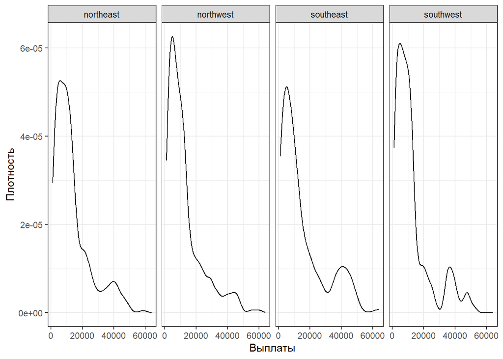

```r
ggplot(data = inc) +
      geom_density(aes(x = charges)) +
        facet_grid(. ~region) +
      theme_bw() +
  labs (y = 'Плотность', x = 'Выплаты')
```

#### **Задание 7.** Постройте scatter plot отношения переменных age и charges. Добавьте названия осей, название графика и тему. Сделайте так, чтобы числа по оси Х отображались 14 шрифтом.

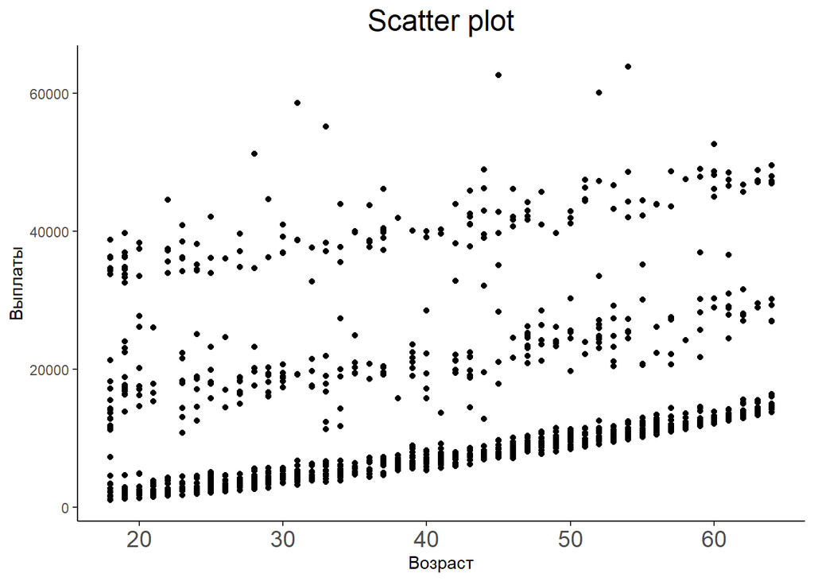

```r
ggplot(data = inc) +
      geom_point(aes(x = age,
                     y = charges)) +
      theme_classic() +
      theme(axis.text.x = element_text(size = 14),
            plot.title = element_text(size = 18, hjust = 0.5)) +
   labs (x = 'Возраст', y = 'Выплаты', title = 'Scatter plot')
```

#### **Задание 8.** Проведите линию тренда для предыдущего графика.

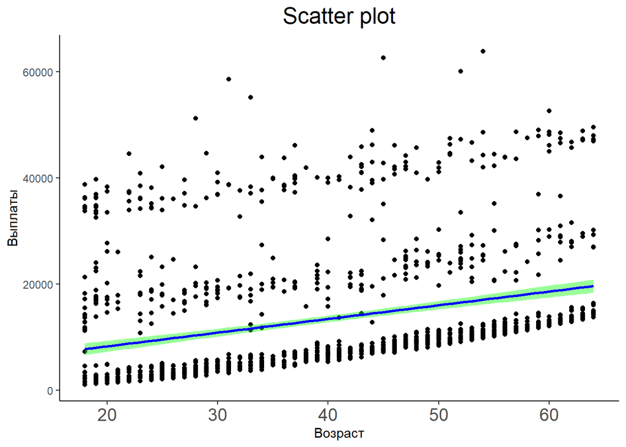

```r
ggplot(data = inc, aes(x = age,
                     y = charges)) +
      geom_point() +
      geom_smooth(method = lm,
                  color = 'blue',
                  fillrange = T,
                  fill = 'green',
                  se = TRUE) +
      theme_classic() +
      theme(axis.text.x = element_text(size = 14),
            plot.title = element_text(size = 18, hjust = 0.5)) +
   labs (x = 'Возраст', y = 'Выплаты', title = 'Scatter plot')
```

#### **Задание 9.** Сделайте разбивку предыдущего графика по колонке smokers (у вас должно получится две линии тренда для курящих и нет).

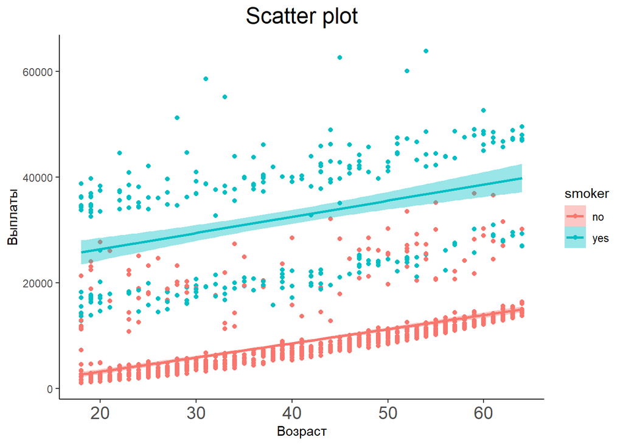

```r
#1 вариант
ggplot(data = inc, aes(x = age,
                     y = charges,
                     color = smoker,
                     fill = smoker,
                     group = smoker)) +
      geom_point() +
      geom_smooth(method = lm,
                  se = TRUE) +
      theme_classic() +
      theme(axis.text.x = element_text(size = 14),
            plot.title = element_text(size = 18, hjust = 0.5)) +
   labs (x = 'Возраст', y = 'Выплаты', title = 'Scatter plot')
```

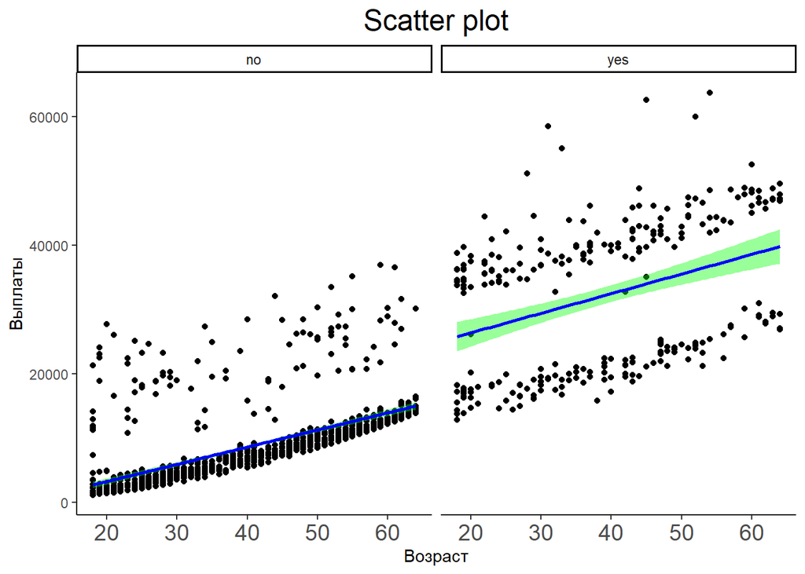

```r
#2 вариант
ggplot(data = inc, aes(x = age,
                     y = charges)) +
facet_grid(. ~smoker) +
      geom_point() +
      geom_smooth(method = lm,
                  color = 'blue',
                  fill = 'green',
                  se = TRUE) +
      theme_classic() +
      theme(axis.text.x = element_text(size = 14),
            plot.title = element_text(size = 18, hjust = 0.5)) +
   labs (x = 'Возраст', y = 'Выплаты', title = 'Scatter plot')
```

#### **Задание 10.** Сделайте график из заданий 7-9, но вместо переменной age используйте переменную bmi.

[figure not shown]

```r
#1 вариант
ggplot(data = inc, aes(x = bmi,
                     y = charges,
                     color = smoker,
                     fill = smoker,
                     group = smoker)) +
      geom_point() +
      geom_smooth(method = lm,
                  color = 'blue',
                  fill = 'green',
                  se = TRUE) +
      theme_classic() +
      theme(axis.text.x = element_text(size = 14),
            plot.title = element_text(size = 18, hjust = 0.5)) +
   labs (x = 'Возраст', y = 'Выплаты', title = 'Scatter plot')
```

[figure not shown]

```r
#2 вариант
ggplot(data = inc, aes(x = bmi,
                     y = charges)) +
facet_grid(. ~smoker) +
      geom_point() +
      geom_smooth(method = lm,
                  color = 'blue',
                  fill = 'green',
                  se = TRUE) +
      theme_classic() +
      theme(axis.text.x = element_text(size = 14),
            plot.title = element_text(size = 18, hjust = 0.5)) +
   labs (x = 'Возраст', y = 'Выплаты', title = 'Scatter plot')
```

#### **Задание 11.** Задайте вопрос к данным №1 (вопрос должен быть про какую-то подвыборку данных). Ответьте на него построив график на подвыборке данных. График должен содержать все основные элементы оформления (название, подписи осей, тему и проч.). Аргументируйте выбор типа графика.

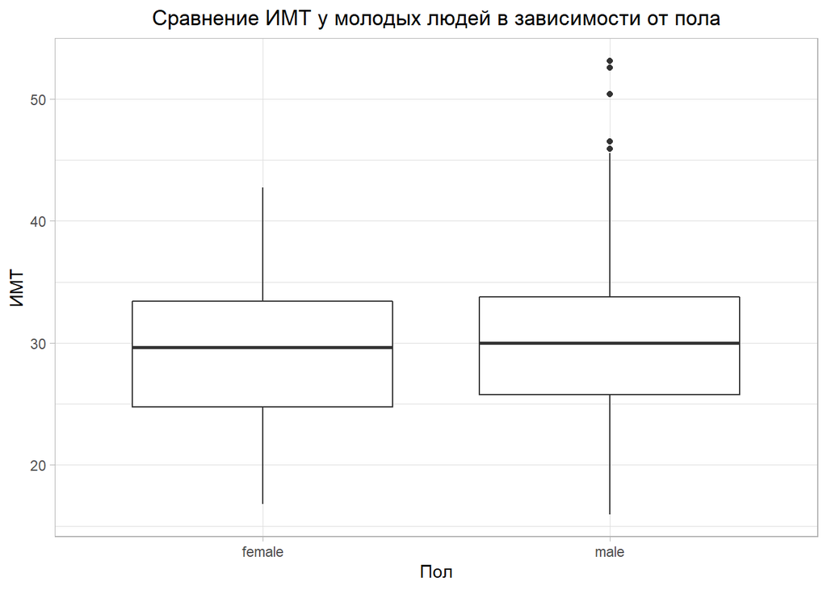

```r
#Меняется ли индекс массы тела от пола у молодых людей (до 30 лет)?

inc1 <- inc[inc$age < 30, ]

ggplot(data = inc1) +
      geom_boxplot(aes(x = bmi, y = sex)) +
      theme_light() +
      theme(plot.title = element_text(hjust = 0.5)) +
  labs (x = 'ИМТ', y = 'Пол', title = 'Сравнение ИМТ у молодых людей в зависимости от пола') +
  coord_flip()
```

```r
#Медианы практически на одном уровне, верхний и нижний квартили у мужчин чуть выше, чем у женщин, так же у мужчин больше выбросов с большим ИМТ. Тип графика показывает медианы. квартили, экстремумы значений, что позволяет оценить различия
```

#### **Задание 12.** Задайте вопрос к данным №2 (вопрос должен быть про какую-то подвыборку данных). Ответьте на него построив график на подвыборке данных. График должен содержать все основные элементы оформления (название, подписи осей, тему и проч.). Аргументируйте выбор типа графика.

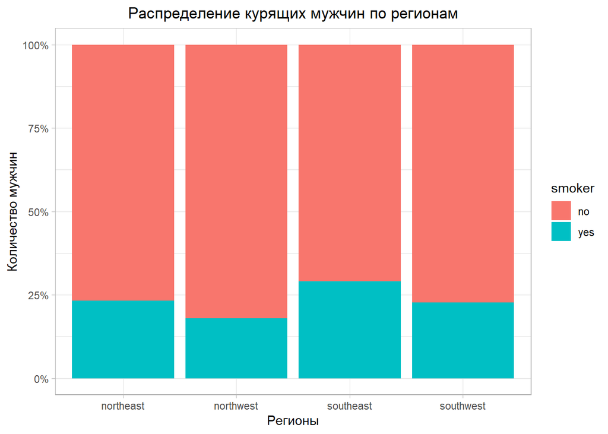

```r
#Найти регион с наибольшим процентом курящих мужчин

inc2 <- inc[inc$sex == 'male', ]

ggplot(data = inc2) +
  geom_bar(aes(x = region, fill = smoker), position = "fill") +
  theme_light() +
  theme(plot.title = element_text(hjust = 0.5)) +
  labs(title = "Распределение курящих мужчин по регионам",
       x = "Регионы",
       y = "Количество мужчин") +
  scale_y_continuous(labels = scales::percent)
```

```r
#В регионе Southeast наибольший процент курящих мужчин. Данный график показывает сравнение именно по процентам, а не по количеству человек
```

#### **Задание 13.** Задайте вопрос к данным №3 (вопрос должен быть про какую-то подвыборку данных). Ответьте на него построив график на подвыборке данных. График должен содержать все основные элементы оформления (название, подписи осей, тему и проч.). Аргументируйте выбор типа графика.

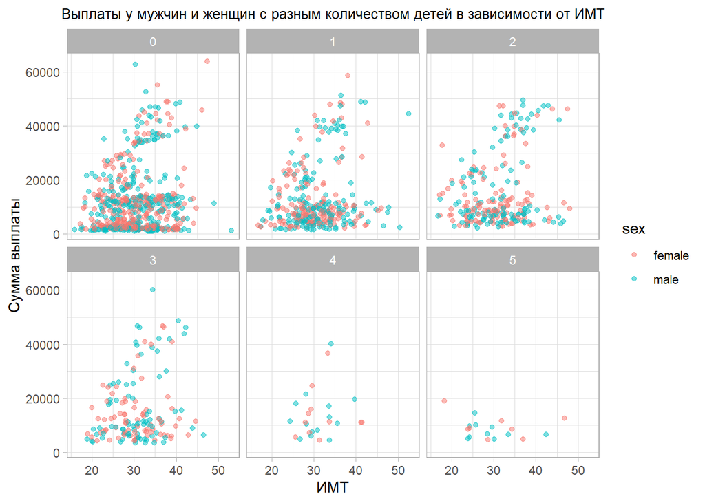

```r
#Как распределяются выплаты у мужчин и женщин в зависимости от ИМТ и есть ли влияние количества детей

ggplot(data = inc) +
  geom_point(aes(x = bmi,
                 y = charges,
                 colour = sex), alpha = 0.5) +
  facet_wrap(~children) +
  theme_light() +
  theme(plot.title = element_text(hjust = 0.5, size = 10)) +
  labs(title = "Выплаты у мужчин и женщин с разным количеством детей в зависимости от ИМТ",
       x = "ИМТ",
       y = "Сумма выплаты")
```

```r
#
```

[output not shown]

#### **Задание 14.** Приблизительно повторите график

```r
library(dplyr)
```

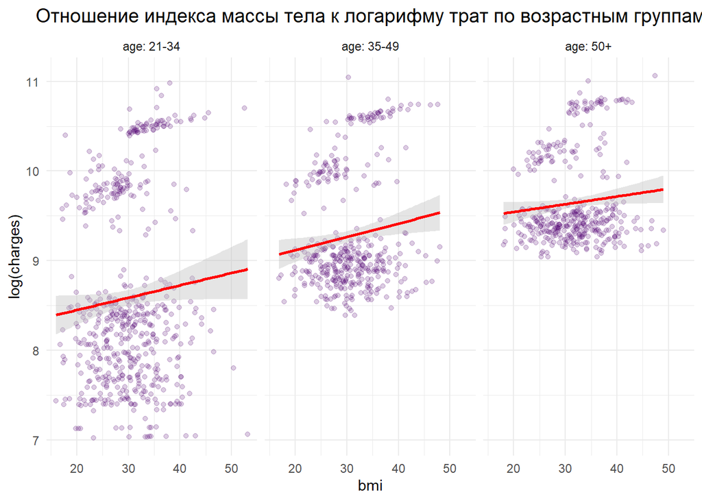

```r
inc_n <- inc %>%
  mutate(
    age_group = case_when(
age < 35 ~ "age: 21-34",
age >= 35 & age < 50 ~ "age: 35-49",
age >= 50 ~ "age: 50+")) %>%
  mutate(log_ch = log(charges))

ggplot(data = inc_n) +
  geom_point(colour = "#4f0070", alpha = 0.2, aes(x = bmi, y = log_ch)) +
  geom_smooth(aes(x = bmi, y = log_ch), method = lm, color = 'red', fill = 'grey', se = TRUE) +
  facet_wrap(~age_group) +
  theme_minimal() +
  theme(plot.title = element_text(hjust = 0.5, size = 14, face = "plain")) +
  labs(title = "Отношение индекса массы тела к логарифму трат по возрастным группам",
       x = "bmi",
       y = "log(charges)") +

  theme(legend.position = "bottom")
```